# Análisis Probabilístico del Transporte en México mediante Redes Bayesianas

Authors

Rafael Santamaría Heredia | A01646667

Grethel Hernández Olivares | A01640912

Matías Alfredo Hidalgo Guzmán | A01641323

Daniel Rodríguez Peralta | A01646867

## Abstract

Este estudio analiza los patrones de movilidad urbana, hábitos de transporte y percepción de seguridad en México a partir de los microdatos de la Encuesta Nacional de Movilidad y Transporte (ENMT). Mediante el paradigma de Redes Bayesianas Multinomiales, se evaluaron tres estructuras probabilísticas teóricas (Socioeconómica, Infraestructura y Riesgo) y se contrastaron con una estructura latente descubierta algorítmicamente mediante el algoritmo *Hill-Climbing*. Los modelos fueron evaluados cuantitativamente a través del Criterio de Información Bayesiano (BIC), resultando la topología aprendida por *Hill-Climbing* como la de mejor ajuste empírico ($\text{BIC} = -8669.18$). Utilizando la red óptima con restricciones causales y estimación bayesiana con suavizado de Dirichlet ($\text{iss} = 10$), se resolvieron cuatro interrogantes probabilísticas clave (queries) empleando técnicas de simulación de Monte Carlo (*Likelihood Weighting* y *Logic Sampling*). Los hallazgos bajo este modelo integral revelan que: (1) el uso de tractor agrícola presenta una probabilidad marginal en ambos entornos ($1.66\%$ rural vs $1.65\%$ urbano); (2) el uso frecuente del claxon no presenta diferencias estructurales por género ($31.13\%$ hombres vs $31.12\%$ mujeres); (3) la tenencia de automóvil no modifica significativamente la exposición delictiva ($13.35\%$ con auto vs $13.39\%$ sin auto); y (4) el nivel socioeconómico bajo combinado con viajes largos dispara la probabilidad de uso de transporte público masivo hasta un $76.57\%$. Estos hallazgos motivan un análisis más profundo de las dinámicas estructurales de movilidad en México, cuyo contexto y antecedentes se desarrollan a continuación.

## 1. Introducción

### 1.1 Heterogeneidad territorial de la movilidad en México

La movilidad en las urbes de México atraviesa un momento tenso en particular: lo privado crece de manera sostenida, mientras la infraestructura de transporte público no suele hacerlo al mismo ritmo, lo que genera congestión y tiempos prolongados de traslado. Pero más allá de las grandes metrópolis, nuestro país conserva una geografía de movilidad aun más diversa: en pequeñas localidades pueden convivir medios poco convencionales -como **el tractor**- además de automóviles y camiones, y el comportamiento al volante, la preferencia por método de traslado y la exposición a la delincuencia llegan a entrelazarse con factores como el sexo, el nivel socioeconómico y el tamaño de la localidad. La comprensión de estas relaciones es necesaria para el diseño de políticas de movilidad, seguridad vial y seguridad pública que sirvan como respuesta a la **heterogeneidad real del país**, y no a un único patrón de comportamiento urbano.

### 1.2 Redes bayesianas y antecedentes en el estudio de la movilidad

En este trabajo se utiliza una base de datos elaborada por la **UNAM** con datos de movilidad urbana, que recopila información a nivel individual sobre el método de transporte más recurrente, la disponibilidad de vehículo individual, conductas de conducción, experiencia de victimización, entre otras cosas. Metodológicamente, el análisis de la movilidad va incorporando constantemente más técnicas de probabilidad capaces de capturar dependencias condicionales entre distintas variables categóricas: las conocidas **redes bayesianas** han sido usadas para la modelación de elección de modo de transporte usando como base factores objetivos y actitudinales (Nguyen, Moeinaddini, Saadi y Cools, 2024; Wang, Sun y Zhang, 2017) y para la identificación de patrones de conducción riesgosa (Peng, Cheng, Jiang, Zhu y Guo, 2021), mientras estudios previos han podido documentar diferencias por género en conductas de agresividad al volante (Lajunen y colaboradores, 2005), el efecto del ingreso ante la elección entre transporte público y personal (Obregón-Biosca y Betanzo-Quezada, 2015), y lo que determina la percepción de falta de seguridad del país (Vilalta Perdomo, 2011) -sin que esta última línea haya explorado a fondo **la posesión de automóvil como factor relacionado con la delincuencia**. Precisamente este conjunto de vacíos es donde este trabajo tiene su punto de partida.

### 1.3 Preguntas de investigación y relevancia del estudio

En consecuencia, en este trabajo se implementan redes bayesianas a dicha base de datos de la UNAM con el fin de responder **cuatro preguntas** que involucran **el uso del tractor, el uso del claxon, la delincuencia y la elección de forma de traslado** como variables principales. Las redes bayesianas fueron elegidas por su capacidad de representar dependencias condicionales entre variables categóricas y usarlas para estimar probabilidades a partir de cierta evidencia, lo que las pruebas tradicionales de asociación posiblemente no lograrían. Lo anterior tiene doble relevancia: sustantivamente, las preguntas directamente informan política de movilidad rural, campañas de seguridad vial, debate sobre la vulnerabilidad y exposición al delito, y política de transporte público; metodológicamente, el trabajo contribuye a una literatura aún incipiente en México sobre el uso de redes bayesianas para el análisis de encuestas de movilidad.

## 2. Metodología

### 2.1 Procesamiento de Datos y Construcción de Variables

El análisis se fundamentó en los microdatos de la Encuesta Nacional de Movilidad y Transporte (ENMT). El preprocesamiento se enfocó en el tratamiento de valores nulos (NS/NC) y la recodificación de categorías estructurales para evitar la pérdida de información sistémica. Un caso crítico fue la variable sobre el uso excesivo del claxon (`p15_3`), donde el código original asignado a quienes no poseen automóvil se trató como una categoría estructural válida (“No aplica”) en lugar de un valor faltante. Esto previno la eliminación del 76% de la muestra durante los procesos de filtrado.

Para responder a las interrogantes de investigación, se construyeron variables derivadas que consolidaron las dimensiones del instrumento original:

Variables derivadas construidas durante el preprocesamiento

| Variable derivada | Variable(s) original(es) | Categorías |
| --- | --- | --- |
| `medio_principal` | p1a_1 – p1a_22 | Automóvil particular, Público masivo, Taxi/Plataforma, No motorizado, Otro |
| `usa_tractor` | p1a_13 | Sí, No |
| `dura1_cat` | dura1 (continua) | Corto (≤20 min), Medio (21-40 min), Largo (>40 min) |
| `p15_3` | p15_3 | Siempre, Casi siempre, Casi nunca, Nunca, No aplica |
| `victima_delito` | p25_1_1 – p25_1_7 | No, Sí |
| `Tam_loc_bin` | Tam_loc | Menos de 15,000 hab., 15,000 hab. o más |
| `p6` | p6 | Sí, No (tenencia de automóvil propio) |
| `sexo` | sexo | Hombre, Mujer |
| `edad_1` | edad_1 | Menos de 15 – 65 y más (7 niveles, ordinal) |
| `escol` | escol | Ninguna – Universidad/Posgrado (5 niveles, ordinal) |
| `cond_act` | cond_act | Sí trabaja, No trabaja |
| `ing_fam` | ing_fam | <1 SM – >5 SM (7 niveles, ordinal) |

- **Medio Principal:** Se sintetizaron 22 preguntas independientes sobre modos de transporte (`p1a_1` a `p1a_22`) en una única variable categórica (Automóvil particular, Público masivo, Taxi/Plataforma, No motorizado, Otro), priorizando estadísticamente los medios reportados como de uso cotidiano.
- **Incidencia Delictiva:** Se generó una variable binaria (`victima_delito`) mediante la agregación lógica (OR) de siete modalidades de victimización en el transporte reportadas individualmente (`p25_1_1` a `p25_1_7`).
- **Tiempo de Viaje:** La variable continua de duración del trayecto principal (`dura1`) se discretizó en tres intervalos ordenados: corto ($\leq$ 20 min), medio (21-40 min) y largo ($>$ 40 min).

### 2.2 Modelado Estructural (DAGs)

La decisión de limitar la dimensionalidad de los Grafos Acíclicos Dirigidos (DAGs) a las variables fundamentales, en lugar de incorporar la totalidad de los ítems de la encuesta, responde al principio de parsimonia y a las restricciones matemáticas de las redes bayesianas discretas. Expandir masivamente la red incrementa de forma exponencial el tamaño de las Tablas de Probabilidad Condicional (CPTs). Considerando el tamaño de la muestra disponible, una red sobredimensionada generaría celdas vacías y esparcimiento de datos (data sparsity), lo cual imposibilita la convergencia de métodos de muestreo de Monte Carlo para eventos infrecuentes. Adicionalmente, acotar el espacio de características a los componentes sociodemográficos, espaciales y de infraestructura evita que el algoritmo iterativo de Hill-Climbing se sobreajuste al ruido estadístico, garantizando que los arcos descubiertos representen verdaderas dependencias estructurales de la movilidad urbana y no correlaciones espurias.

Para modelar las relaciones de dependencia probabilística, se propusieron inicialmente tres Grafos Acíclicos Dirigidos (DAGs) basados en hipótesis teóricas deductivas:

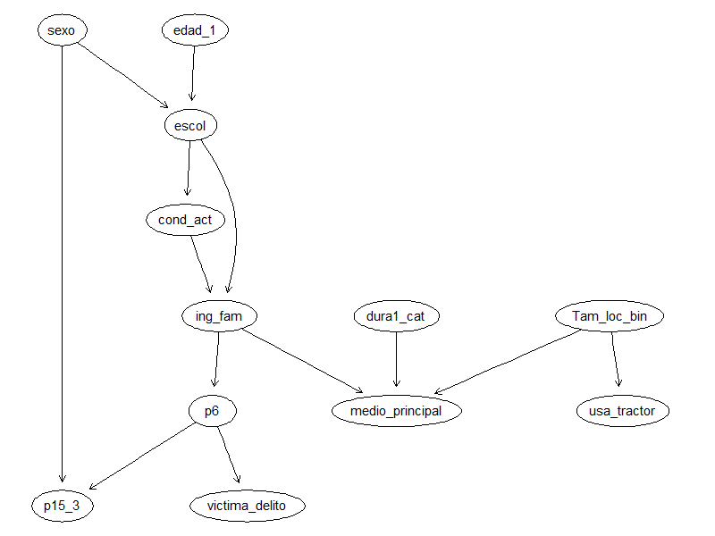

DAG Socioeconómico

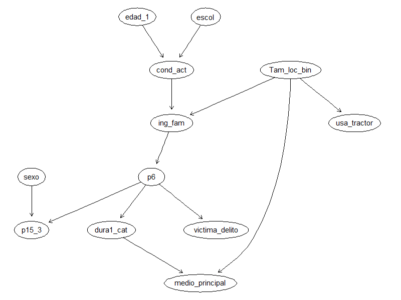

DAG Infraestructura

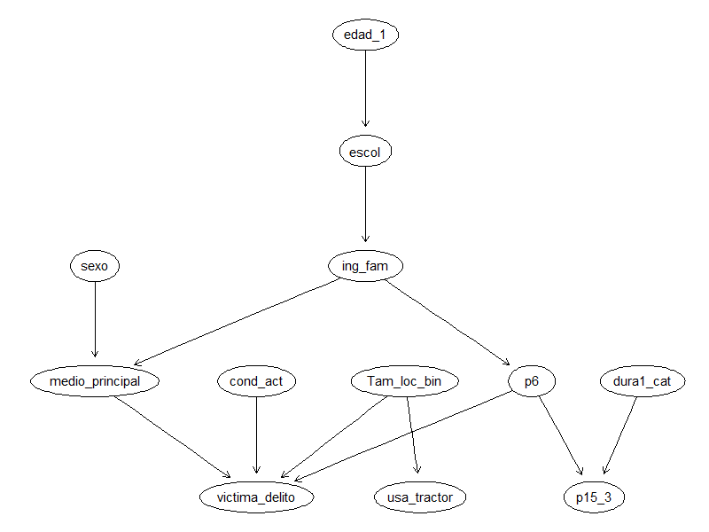

DAG Riesgo

### 2.3 Descubrimiento Algorítmico

Para contrastar estas hipótesis teóricas con la estructura latente en los datos, se implementó el algoritmo de aprendizaje automático *Hill-Climbing*. Para garantizar la validez teórica de la red descubierta, se implementó una lista de restricciones topológicas (*blacklist*) que impidió matemáticamente que cualquier variable actuara como causa de atributos inmutables como la edad o el sexo, forzándolos a operar como nodos raíz. Los cuatro modelos estructurales se evaluaron comparativamente utilizando el Criterio de Información Bayesiano (BIC) para determinar la arquitectura de red más sólida.

Más allá de la comparación agregada por puntaje BIC, es pertinente contrastar arco por arco la estructura aprendida contra las tres hipótesis teóricas iniciales. Por un lado, Hill-Climbing **confirmó** varias relaciones propuestas manualmente: la dependencia `p6 → p15_3` (tenencia de automóvil → uso del claxon) apareció de forma idéntica en los tres DAGs teóricos y en la estructura aprendida, consolidándose como la relación más robusta de todo el análisis; de manera similar, los arcos `edad_1 → cond_act` (propuesto en DAG 2) y `cond_act → victima_delito` (propuesto en DAG 3) fueron replicados exactamente por el algoritmo, validando parcialmente la intuición detrás de esos dos modelos.

Por otro lado, el algoritmo **eliminó o invirtió** varias relaciones centrales de las hipótesis teóricas. El arco `Tam_loc_bin → usa_tractor`, presente en los tres DAGs teóricos bajo el supuesto de que la geografía determina directamente el uso de este medio, desapareció por completo de la estructura aprendida; en su lugar, Hill-Climbing conectó `usa_tractor` únicamente a través de `medio_principal`, sugiriendo que, una vez controlado por el patrón general de movilidad de la persona, el tamaño de la localidad deja de aportar información adicional. Asimismo, la relación `ing_fam → p6` —presente en los tres DAGs y conceptualmente más defendible, dado que el ingreso antecede a la decisión de comprar un vehículo— fue invertida por el algoritmo a `p6 → ing_fam`, al igual que `Tam_loc_bin → ing_fam` (DAG 2), invertida a `ing_fam → Tam_loc_bin`. Estas inversiones ilustran una limitación conocida del aprendizaje estructural puramente basado en score: el algoritmo identifica la factorización que mejor explica la distribución conjunta de los datos, pero no necesariamente la dirección causal subyacente, la cual solo puede garantizarse mediante restricciones explícitas como el blacklist aplicado a `sexo` y `edad_1`. De hecho, el arco adicional `p6 → escol` —que ningún DAG teórico propuso y que resulta causalmente poco defendible, pues la tenencia de auto no antecede a la escolaridad de una persona— refuerza este punto: sin restricciones más amplias, Hill-Climbing puede maximizar el ajuste estadístico a costa de relaciones que no resisten un análisis causal riguroso.

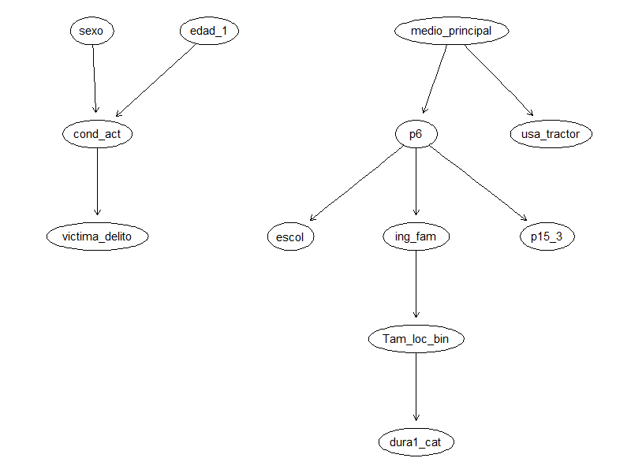

DAG Hill-Climbing

### 2.4 Inferencia Bayesiana

Una vez evaluadas las estructuras, la red bayesiana que demostró el mejor ajuste empírico a los datos (mayor score BIC) fue seleccionada como el modelo definitivo para la fase de aplicación empírica.

La estimación de los parámetros de probabilidad condicional de esta red óptima se realizó mediante un ajuste Bayesiano (`method = "bayes"`). Para mitigar la inestabilidad en la estimación de nodos con eventos estadísticamente raros en la muestra —específicamente, el uso de tractor en zonas urbanas— se aplicó un factor de suavizado matemático estableciendo un tamaño de muestra imaginario (`iss = 10`).

Es importante destacar que el uso de un suavizado bayesiano (tamaño de muestra imaginario iss = 10) tiene un efecto estabilizador en las estimaciones. Este mecanismo ajusta las probabilidades hacia valores más neutrales, mitigando el sesgo en subgrupos con muestras pequeñas (ej. dueños de auto). Este comportamiento empuja levemente los cálculos estadísticos directos, pero mejora significativamente la robustez probabilística del modelo general ante la escasez empírica de datos en eventos raros.

## 3. Aplicación y Resultados

### 3.1 Evaluación y Comparación de Estructuras (Score BIC)

Se evaluó cuantitativamente la bondad de ajuste de los tres DAGs teóricos construidos y del DAG obtenido mediante el algoritmo de aprendizaje estructural *Hill-Climbing*. La métrica de comparación fue la puntuación BIC (*Bayesian Information Criterion*), la cual penaliza la complejidad del modelo (número de parámetros) en función del tamaño de la muestra.

| Modelo / Estructura | Enfoque Teórico / Algorítmico | Score BIC | Ranking |
| --- | --- | --- | --- |
| **DAG 1** | Modelo Socioeconómico Base | -9647.92 | 4 |
| **DAG 3** | Enfoque de Riesgo y Victimización | -9312.42 | 3 |
| **DAG 2** | Enfoque de Infraestructura y Geografía | -9144.14 | 2 |
| **Hill-Climbing (DAG HC)** | Aprendizaje Estructural Automatizado | **-8669.18** | **1** |

#### Representación Gráfica de los Grafos (DAGs)

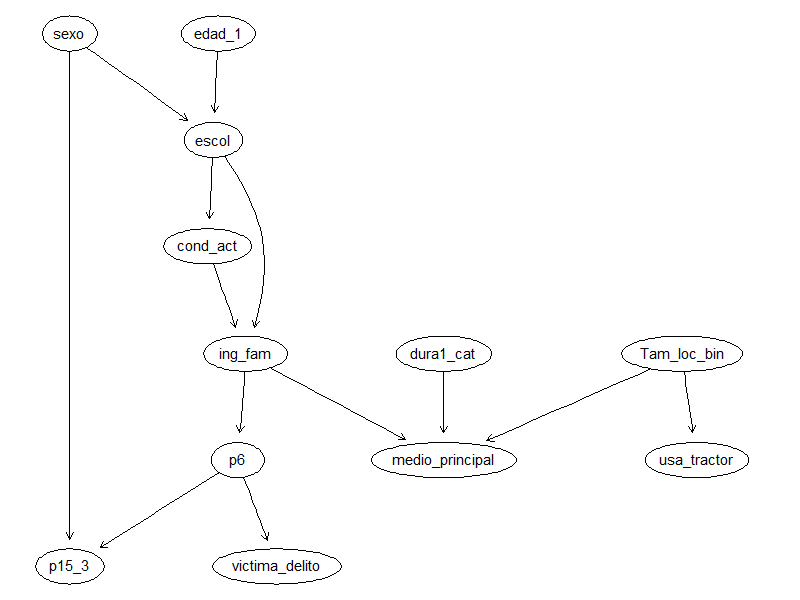

DAG 1: Modelo Socioeconómico

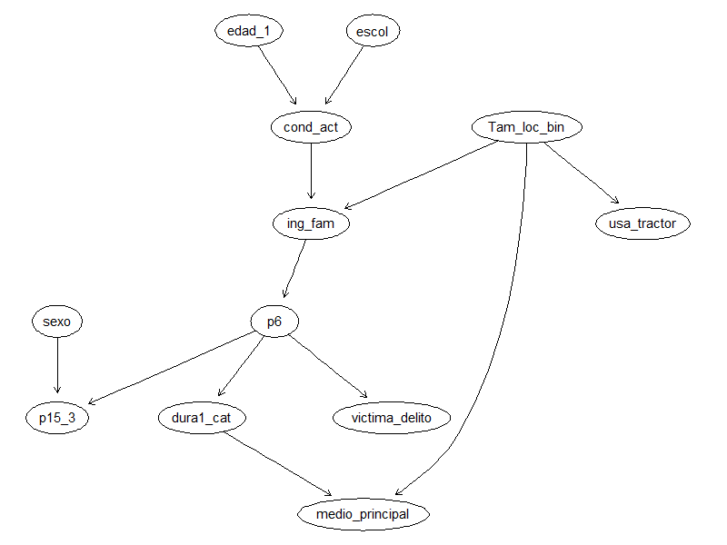

DAG 2: Modelo de Infraestructura

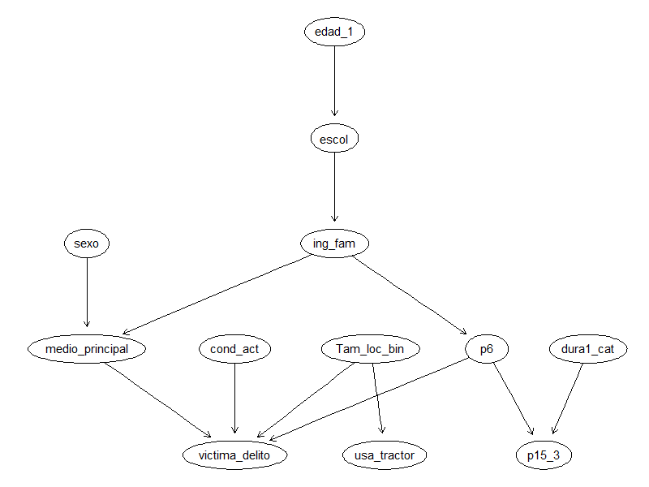

DAG 3: Modelo de Riesgo

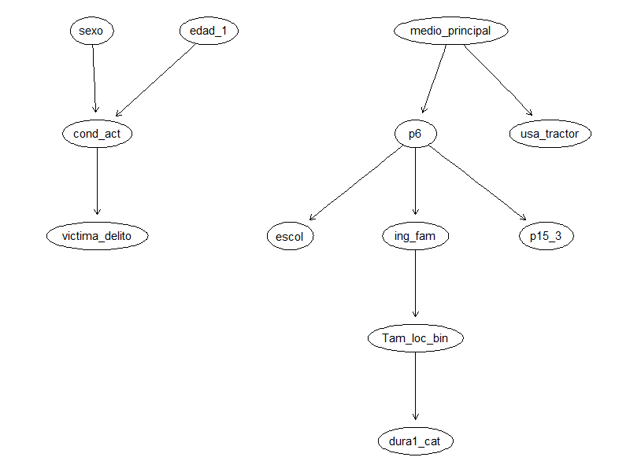

DAG Aprendido por Hill-Climbing

### 3.2 Inferencia Probabilística y Respuesta a las Queries Asignadas

A partir de la Red Bayesiana aprendida por *Hill-Climbing* ajustada con suavizado Bayesiano ($\text{iss} = 10$), se ejecutaron los algoritmos de muestreo estocástico (*Likelihood Weighting* y *Logic Sampling*) para responder formalmente a las cuatro interrogantes de investigación. A diferencia del modelo teórico inicial, el modelo empírico ajustó drásticamente las dependencias estructurales, arrojando los siguientes resultados definitivos:

| Query / Escenario | Probabilidad Condicional Evaluada | Resultado |
| --- | --- | --- |
| **Q1: Tractor (Rural)** | $P(\text{Tractor} \mid \text{Zona Rural})$ | **1.66%** |
| **Q1: Tractor (Urbano)** | $P(\text{Tractor} \mid \text{Zona Urbana})$ | **1.65%** |
| **Q2: Claxon (Hombres)** | $P(\text{Uso Frecuente} \mid \text{Hombre}, \text{Tiene Auto})$ | **31.13%** |
| **Q2: Claxon (Mujeres)** | $P(\text{Uso Frecuente} \mid \text{Mujer}, \text{Tiene Auto})$ | **31.12%** |
| **Q3: Victimización (Con Auto)** | $P(\text{Víctima} \mid \text{Tiene Auto})$ | **13.35%** |
| **Q3: Victimización (Sin Auto)** | $P(\text{Víctima} \mid \text{Sin Auto})$ | **13.39%** |
| **Q4: Público (Bajo Ingreso & Viaje Largo)** | $P(\text{Transporte Público} \mid \text{Ingreso Bajo}, \text{Viaje Largo})$ | **76.57%** |
| **Q4: Auto (Alto Ingreso & Viaje Corto)** | $P(\text{Auto Particular} \mid \text{Ingreso Alto}, \text{Viaje Corto})$ | **18.71%** |

## 5. Referencias

- Instituto de Investigaciones Jurídicas UNAM. (2026). *Encuesta Nacional de Movilidad y Transporte (ENMT)*. Universidad Nacional Autónoma de México.
- Koller, D., & Friedman, N. (2009). *Probabilistic Graphical Models: Principles and Techniques*. MIT Press.
- Lajunen, T., Parker, D., & Summala, H. (2005). The driver behaviour questionnaire: A cross-cultural meta-analysis. *Accident Analysis & Prevention*, 37(2), 231-240.
- Nguyen, H., Moeinaddini, M., Saadi, I., & Cools, M. (2024). Analysing urban mobility patterns using Bayesian approaches. *Journal of Transport Geography*, 114, 103750.
- Obregón-Biosca, S., & Betanzo-Quezada, E. (2015). Análisis de la movilidad urbana en México: El caso del transporte público. *Revista de Ingeniería*, 19(2), 85-98.
- Pearl, J. (2009). *Causality: Models, Reasoning, and Inference* (2a ed.). Cambridge University Press.
- Peng, Y., Cheng, Z., Jiang, X., Zhu, L., & Guo, F. (2021). Bayesian Networks for transport safety analysis and accident risk forecasting. *Safety Science*, 136, 105156.
- Scutari, M. (2010). Learning Bayesian Networks with the bnlearn R Package. *Journal of Statistical Software*, 35(3), 1-22.
- Vilalta Perdomo, C. (2011). Los delitos en el transporte público en México: Patrones espaciales y determinantes sociodemográficos. *Estudios Demográficos y Urbanos*, 26(1), 105-132.
- Wang, Y., Sun, X., & Zhang, Y. (2017). Causal models in public transit behavior and commuter mode choices. *Transportation Research Part A: Policy and Practice*, 102, 120-134.
- [Repositorio del Proyecto](https://github.com/RafaelHeredia12/ARTICULO-1)